# Problema 1

Analisaremos as temporadas das séries de comédia: The Big Bang Theory, Brooklyn Nine-Nine, Modern Family, Two And a Half Men

```r
dados = read_csv(here("data/series_from_imdb.csv"),
                    progress = FALSE,
                    col_types = cols(.default = col_double(),
                                     series_name = col_character(),
                                     episode = col_character(),
                                     url = col_character(),
                                     season = col_character())) %>%
    filter(series_name %in% c("Two And a Half Men", "The Big Bang Theory","Brooklyn Nine-Nine","Modern Family"))
```

## 2.1 Qual das séries que você escolheu é mais bem avaliada no IMDB? A diferença é grande? Pequena?

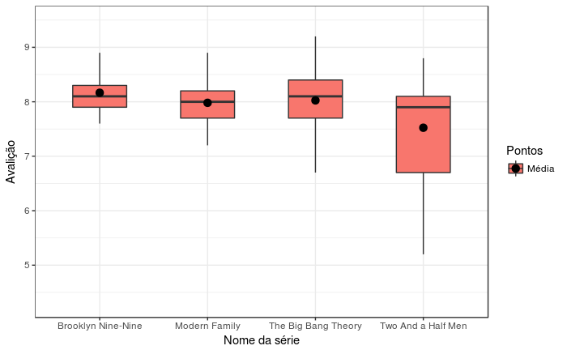

```r
sumarios = dados %>%
    group_by(series_name) %>%
    summarise(mediana = median(user_rating),
              media = mean(user_rating))
dados %>%
    ggplot(aes(x = series_name, y = user_rating,  fill="Média")) +
    geom_boxplot(width = .5, outlier.color = NA) +
  stat_summary(fun.y="mean", geom="point", size=3,
    position=position_dodge(width=0.75), color="black")+
    labs(x="Nome da série", y= "Avalição", fill="Pontos")
```

A série mais bem avaliada em média é a série Brooklyn Nine-Nine, porém, a diferença entre as séries é muito pequena, e seus valores médios tendem a se aproximar de 8.

## 2.2 Muda de acordo com as temporadas da série?

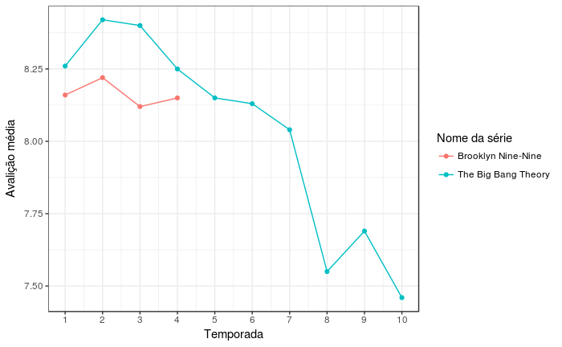

```r
sumarios <- dados %>%
    filter(series_name %in% c("The Big Bang Theory","Brooklyn Nine-Nine")) %>%
    group_by(series_name,season) %>%
    summarise(
        season_rating = round(mean(user_rating),2))
  sumarios$season <- as.numeric(as.character(sumarios$season))
  ggplot(sumarios ,aes(x = season, y = season_rating, color = series_name,group=series_name)) +
  geom_line() +
  geom_point() +
  scale_x_continuous(breaks = (1:12))+
  labs(x="Temporada", y= "Avalição média", color="Nome da série")
```

Apesar de ser a série em média mais bem avaliada, Brooklyn Nine-Nine é consideravelmente inferior a The Big Bang Theory nas primeiras temporadas, porém, The Big Bang Theory teve um decréscimo com o decorrer das temporadas e acabou contabilizando uma avaliação média inferior a Brooklyn Nine-Nine

## 2.3 Qual das séries tem episódios de qualidade mais irregular segundo o IMDB?

#### A irregularidade será julgada pelo espaçamento dos dados analisados nos box-plots da seção 2.1

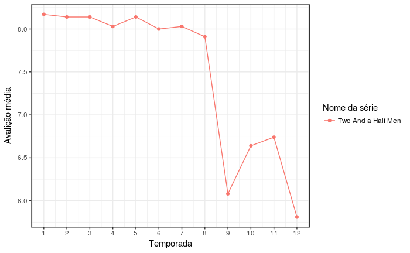

```r
sumarios <- dados %>%
    filter(series_name %in% c("Two And a Half Men")) %>%
    group_by(series_name,season) %>%
    summarise(
        season_rating = round(mean(user_rating),2))
sumarios$season <- as.numeric(as.character(sumarios$season))
  ggplot(sumarios ,aes(x = season, y = season_rating, color = series_name,group=series_name)) +
  geom_line() +
  geom_point() +
  scale_x_continuous(breaks = (1:12))+
  labs(x="Temporada", y= "Avalição média", color="Nome da série")
```

Observando os blox-plots da seção 2.1, percebe-se que Two And a Half Men é a série mais irregular segundo o IMDB, pois existe uma decrepância enorme a partir da 9° temporada da série, isso se deve ao fato da saída do ator Charlie Sheen que era muito aclamado na série.

## Extra: O que tende a ser melhor? Inícios ou finais de séries/temporadas?

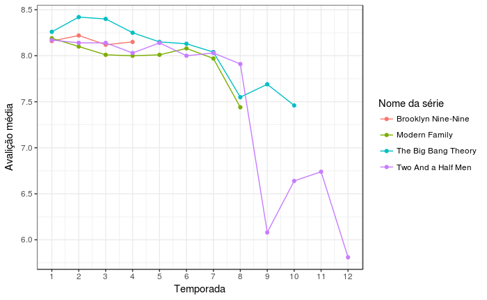

```r
sumarios <- dados %>%
    group_by(series_name,season) %>%
    summarise(
        season_rating = round(mean(user_rating),2))
  sumarios$season <- as.numeric(as.character(sumarios$season))
  ggplot(sumarios ,aes(x = season, y = season_rating, color = series_name,group=series_name)) +
  geom_line() +
  geom_point() +
  scale_x_continuous(breaks = (1:12))+
  labs(x="Temporada", y= "Avalição média", color="Nome da série")
```

De acordo com o gráfico, os inícios das séries de comédia tendem a ser melhor que os finais, isso pode ser pelo fato do humor se tornar obsoleto com o decorrer das temporadas.